# Uebungserie_7_stern_nicolas

Nicolas Stern

6 décembre 2018

# Stetige Gleichverteilung

Aufgabe: Sie haben um 9 Uhr ein wichtiges Meeting, aber Sie verschlafen und wachen erst um 8:30 Uhr auf. Um 8:40 rennen Sie aus der Tür, auf dem Weg ins Büro. Sie brauchen 6 Minuten zur Bushaltestelle. Sie warten auf den Bus, der morgens alle fünf Minuten kommt, die Wartezeit in Minuten ist gleichverteilt zwischen 0 und 5. Der Bus braucht zwischen 10 bis 15 Minuten (gleichverteilt) bis ins Büro. Modellieren Sie Ihre Reisezeit mit einer einzigen Variablen X.

- Welche Verteilung hat die Zufallsvariable X, welche die gesamte Pendelzeit von Haustür bis ins Büro beschreibt?
- Antwort: X ~ 16 + U(0, 10).

Begründung: Reisezeit setzt sich aus folg. konstante Zeiten:

- 6 Minunten Gehzeit
- 10 Minuten minimale Bus-Fahrt

… und aus folgende gleichverteilte Zeiten:

- 0-5 Minuten Wartezeit
- 0-5 Minuten Bus-Fahrt zusätzlich zu den 10 Minuten minimal Reisezeit.

d.h. X ~ 16 + U(0,10)

- Mit welcher Wahrscheinlichkeit schaffen Sie es noch rechtzeitig ins Büro?
- Antwort : Die fixe Zeite setzen sich aus 6 Minuten Gehzeit bis zur Bushaltestelle, und 10 Minunten minimum Bus - Reisezeit. Die Variable Zeite setzen sich auf der 0 bis 5 Minuten Wartezeit (gleichverteilt) und die 0 bis 5 Minuten zusätzliche Reisezeit im Bus (auch gleichverteilt). Die Wahrscheinlichkeit, dass ich es rechzeitig ins Büro schaffe ist dann gleich der Wahrscheinlickeit, dass die Variable Zeitabschnitten (Wartezeit + Reisezeit nach 10’) zusammen weniger als 4 Minuten dauern. Mit punif berechnet man diese Wahrscheinlichkeit:

```r
p.on.time <- punif(4, 0, 10, lower.tail = T)
```

```
## [1] "Wahrscheinlichkeit, dass ich rechtzeitig ins Büro ankomme:  0.4"
```

# Exponentialverteilung

In einer vierwöchigen Datenerhebung missen Sie die Länge der Telefongespräche,die Sie auf Ihrem Handy führen. Sie finden heraus, dass die Dauer der Gespräche (in Minuten) einer Exponentialverteilung folgt, und Ihre Gespräche im Erwartungswert 3 Minuten lang sind

### Aufgabe:

1. Welche Verteilung hat die Zufallsvariable X, welche die Dauer der Telefongespräche in Minuten beschreibt?
- Antwort: Die Verteilung ist mit folgender Funktion beschrieben: $\lambda * e^{-\lambda*x}$

Graphische Darstellung, mit Einsetzer der Werten $\lambda$ = 1/3 (Rate pro Minute eines Gespräches, also 3 Minuten per Gespräch, d.h. 1/3 per Minute).

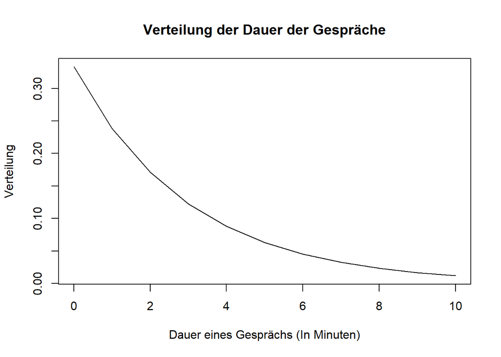

```r
xvalues <- seq(0, 10, length=11)
plot(xvalues, dexp(xvalues, rate=1/3), type = "l",
     ylab = "Verteilung",
     xlab = "Dauer eines Gesprächs (In Minuten)",
     main= "Verteilung der Dauer der Gespräche")
```

2. Das Telefon klingelt. Wie gross ist die Wahrscheinlichkeit, dass dieses Gespräch höchstens eine Minute dauert?
- Antwort: Die Wahrscheinlichkeit ist durch die kumulierte Verteilung gegeben.

```r
round(pexp(1, rate=1/3), 2)
```

```
## [1] 0.28
```

D.h., die Wahrscheinlichkeit beträgt ca. 28 %, dass ein Gespräch höchstens eine Minute dauert.

3. Wie gross ist die Wahrscheinlichkeit, dass das Gespräch länger als eine Minute dauert?
- Antwort : Die Wahrscheinlichkeit ist durch die Fläche unter der Funktionskurve gegeben. Da die Fläche 1 beträgt, kann man die Wahrscheinlichkeit wie folgt berechnen:

```r
p.phone.less.1 <- 1 - round(pexp(1, rate=1/3), 2)
```

D.h., die Wahrscheinlichkeit beträgt ca. 72 %, dass ein Gespräch mindestens eine Minute dauert.

3. Mit welcher Wahrscheinlichkeit dauert das Gespräch zwischen einer und drei Minuten?
- Antwort : diese Wahrscheinlichkeit ist wieder durch die Fläche unter der Funktionskurve gegeben: Da die Fläche 1 beträgt, kann man die kumulierte Wahrscheinlichkeit für 1 Minute-Gespräch von der kumulierten Wahrscheinlichkeit für 3 Minuten-Gespräch substrahieren:

```r
round(pexp(3, rate=1/3) - pexp(1, rate=1/3),2)
```

```
## [1] 0.35
```

D.h., die Wahrscheinlichkeit beträgt ca. 35 %, dass ein Gespräch zwischen eine und 3 Minuten dauert.

4. Berechnen und interpretieren Sie das 25%-Quantil dieser Verteilung.
- Antwort :

```r
qexp(0.25, rate=1/3, lower.tail = T)
```

```
## [1] 0.8630462
```

- Interpretation : 1 / 4 aller Gespräche dauern weniger als 86% einer Minute (oder ca. 51 Sekunden).

# Normalverteilung

## Aufgabe :

In einer Fabrik werden Tüten mit Kartoffelchips befüllt. Das durchschnittlicheGewicht der Tüten soll nach den Angaben des Werkes 200 g betragen. Da die Tüten maschinell befüllt werden, wird dieser Wert nur mit einer Standardabweichung von 4 g eingehalten.

```r
p.between.198.202 <- pnorm(q = 202, mean = 200, sd = 4, lower.tail = T) - pnorm(q = 198, mean = 200, sd = 4, lower.tail = T)
```

```
## [1] "Wahrscheinlichkeit, dass der Gewicht einer Tüte zwischen 198 und 202 g beträgt: 0.38"
```

2. über 205 g liegt?

```r
p.over.205 <- pnorm(q = 205, mean = 200, sd = 4, lower.tail = F)
```

```
## [1] "Wahrscheinlichkeit, dass der Gewicht einer Tüte ueber 205 g beträgt: 0.11"
```

3. Welches Gewicht wird von 95% der Tüten überschritten?
- Antwort: Wert auf der x-Achse wird über die R-Funktion qnorm berechnet.

```r
weight.95.percent <- qnorm(p=0.95, mean = 200, sd = 4, lower.tail = F)
```

```
## [1] "Gewicht, das von 95% der Tüten überschritten wird :  193.42"
```

# $\chi^2$ -Verteilung

### Aufgabe:

- Mit welcher Wahrscheinlichkeit liegt der Wert einer $\chi^2$ - Verteilung mit df = 11 über 15?
- Antwort: Wahrscheinlichkeit p wird mit R-Funktion pchisq(x, df) berechnet. Wahrscheinlichkeit, dass der Wert über ein Referenzwert liegt, wird mit 1 - pchisq(x, df) berechnet.

```r
p.above.15 <- 1-pchisq(15, df=11)
```

```
## [1] "Wahrscheinlichkeit, dass der Wert der Chi-quadrat-Verteilung bei 11 Freiheitsgrade über 15 liegt: 0.18"
```

# T-Student Verteilung

### Aufgabe:

- Mit welcher Wahrscheinlichkeit liegt der Wert der Studentschen t-Verteilung unter -0.5, respektive unter 1? Der Freiheitsgrad sei 7.
- Antwort: Wahrscheinlichkeit p is mit R-Funktion pt(x, df) zu berechnen.

```r
p.under.05 <- pt(-0.5, df=7)
p.under.1 <- pt(1, df=7)
```

```
## [1] "Wahrscheinlichkeit, dass der Wert der Student-T-Verteilung bei 7 Freiheitsgrade unter -0.5 liegt: 0.32"
```

```
## [1] "Wahrscheinlichkeit, dass der Wert der Student-T-Verteilung bei 7 Freiheitsgrade unter 1 liegt: 0.82"
```

# Schiefe

### Aufgabe:

- Bestimmen Sie die Schiefe der Wartezeiten von Faithful.
- Antwort: Schiefe mit der R-Funktion skewness berechnen.

```r
library(e1071)
wait <- faithful$waiting
sk <- skewness(wait)
```

```
## [1] "Schiefe der Wartezeite aus Faithful:  -0.41"
```

- Interpretation: negative Schiefe weist auf einer Linkschiefe darauf hin.

# Kurtosis

### Aufgabe:

- Bestimmen Sie die Kurtosis der Wartezeiten von Faithful.
- Antwort:

```r
kur <- kurtosis(wait)
```

```
## [1] "Kurtosis der Wartezeite aus Faithful:  -1.16"
```

- Interpretation: negative Kurtosis : Die Faithful Wartezeite haben weniger Aussreiser als eine Normalverteilung.